# TRABAJO FINAL

## **MODELO 2**

### **SUPUESTOS:**

*ANALIZANDO EL MODELO 2 SIN FACTOR 2:*

```r
library(lm.beta)
modelo2$coefficients
```

```
##    (Intercept)        factor1  TasaMigracion      Desempleo Crecimientopob
##    586.6458934     19.6785780      0.4782728    -21.1944658   -242.9920296
```

**LINEALIDAD**

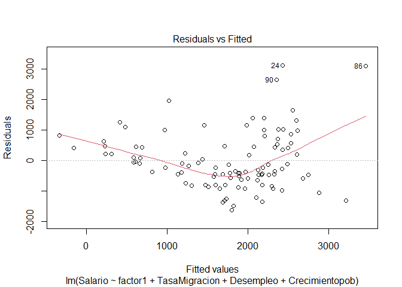

```r
library(ggfortify)
plot(modelo2,1)
```

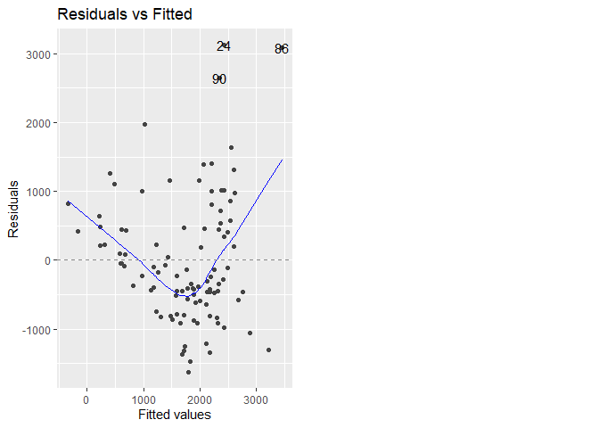

```r
autoplot(modelo2,1)
```

```r
cor.test(DL$Salario, DL$factor1)
```

```
##
##  Pearson's product-moment correlation
##
## data:  DL$Salario and DL$factor1
## t = 7.2034, df = 99, p-value = 1.168e-10
## alternative hypothesis: true correlation is not equal to 0
## 95 percent confidence interval:
##  0.4415892 0.7014634
## sample estimates:
##       cor
## 0.5864183
```

```r
cor.test(DL$Salario, DL$TasaMigracion)
```

```
##
##  Pearson's product-moment correlation
##
## data:  DL$Salario and DL$TasaMigracion
## t = 2.1911, df = 99, p-value = 0.03079
## alternative hypothesis: true correlation is not equal to 0
## 95 percent confidence interval:
##  0.02047807 0.39393846
## sample estimates:
##       cor
## 0.2150566
```

```r
cor.test(DL$Salario, DL$Desempleo) #no funciona
```

```
##
##  Pearson's product-moment correlation
##
## data:  DL$Salario and DL$Desempleo
## t = -0.7575, df = 99, p-value = 0.4505
## alternative hypothesis: true correlation is not equal to 0
## 95 percent confidence interval:
##  -0.2673847  0.1213269
## sample estimates:
##         cor
## -0.07591243
```

```r
cor.test(DL$Salario, DL$Crecimientopob)
```

```
##
##  Pearson's product-moment correlation
##
## data:  DL$Salario and DL$Crecimientopob
## t = -5.4937, df = 99, p-value = 3.057e-07
## alternative hypothesis: true correlation is not equal to 0
## 95 percent confidence interval:
##  -0.6202045 -0.3179500
## sample estimates:
##        cor
## -0.4833537
```

**DL$Salario and DL$factor1:** - P-value = 1.168e-10, si hay linealidad

**DL$Salario and DL$TasaMigracion:** - P-value = 0.03079, si hay linealidad

**DL$Salario and DL$Desempleo:** - P-value = 0.4505, no hay linealidad

**DL$Salario and DL$Crecimientopob:** - P-value = 3.057e-07, si hay linealidad

**NORMALIDAD**

```r
shapiro.test(modelo2$resid)
```

```
##
##  Shapiro-Wilk normality test
##
## data:  modelo2$resid
## W = 0.93708, p-value = 0.0001187
```

*- H0: Es normal*

*- H1: No es normal*

- No hay normalidad de residuos.

**HOMOCEDASTICIDAD**

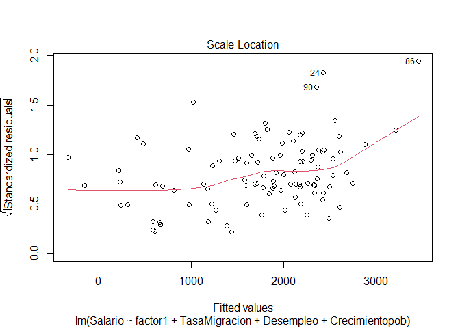

```r
plot(modelo2, 3)
```

```r
library(lmtest)
bptest(modelo2)
```

```
##
##  studentized Breusch-Pagan test
##
## data:  modelo2
## BP = 10.267, df = 4, p-value = 0.03617
```

*- H0: El modelo es homocedástico*

*- H1: El modelo es heterocedástico*

**NO MULTICOLENALIDAD**

```r
library(DescTools)
VIF(modelo2)
```

```
##        factor1  TasaMigracion      Desempleo Crecimientopob
##       2.145916       1.293612       1.012809       2.111471
```

*Valores > 5 indican presencia de multicolinealidad.* No hay multicolinealidad

**INDEPENDENCIA DE RESIDUOS**

```r
#Default
library(car)
durbinWatsonTest(modelo2)
```

```
##  lag Autocorrelation D-W Statistic p-value
##    1     0.009462506      1.959796   0.838
##  Alternative hypothesis: rho != 0
```

*Durbin Watson: Las hipótesis son:* *- H0: Los residuos son independientes*

*- H1: Los residuos no son independientes*

Si hay independencia de residuos.

## **MODELO 3**

### **SUPUESTOS:**

Para este modelo se probarán con todas las variables

```r
modelo3= lm(Salario ~ Migracion + Tasaalfabetizacion + PBI + Educaterciaria + Educsecun + Esperanzavida + Desempleo + Crecimientopob + Electricidad, DL)
summary(modelo3)
```

```
##
## Call:
## lm(formula = Salario ~ Migracion + Tasaalfabetizacion + PBI +
##     Educaterciaria + Educsecun + Esperanzavida + Desempleo +
##     Crecimientopob + Electricidad, data = DL)
##
## Residuals:
##     Min      1Q  Median      3Q     Max
## -1276.7  -491.9  -157.0   381.2  2956.1
##
## Coefficients:
##                      Estimate Std. Error t value Pr(>|t|)
## (Intercept)        -5.930e+03  1.597e+03  -3.712 0.000354 ***
## Migracion           1.956e-04  8.293e-04   0.236 0.814048
## Tasaalfabetizacion  2.786e+00  1.028e+01   0.271 0.786908
## PBI                -4.170e+01  1.931e+01  -2.160 0.033417 *
## Educaterciaria     -8.955e+02  3.562e+02  -2.514 0.013685 *
## Educsecun           1.383e+03  9.352e+02   1.479 0.142635
## Esperanzavida       1.202e+02  1.843e+01   6.521 3.84e-09 ***
## Desempleo           2.692e+00  1.871e+01   0.144 0.885909
## Crecimientopob     -1.828e+02  8.800e+01  -2.077 0.040578 *
## Electricidad       -1.574e+01  7.340e+00  -2.144 0.034688 *
## ---
## Signif. codes:  0 '***' 0.001 '**' 0.01 '*' 0.05 '.' 0.1 ' ' 1
##
## Residual standard error: 837.7 on 91 degrees of freedom
## Multiple R-squared:  0.5515, Adjusted R-squared:  0.5072
## F-statistic: 12.44 on 9 and 91 DF,  p-value: 1.22e-12
```

```r
library(lm.beta)
modelo3$coefficients
```

```
##        (Intercept)          Migracion Tasaalfabetizacion                PBI
##      -5.929656e+03       1.956259e-04       2.786344e+00      -4.170308e+01
##     Educaterciaria          Educsecun      Esperanzavida          Desempleo
##      -8.955007e+02       1.383080e+03       1.201675e+02       2.691689e+00
##     Crecimientopob       Electricidad
##      -1.828123e+02      -1.573842e+01
```

**LINEALIDAD**

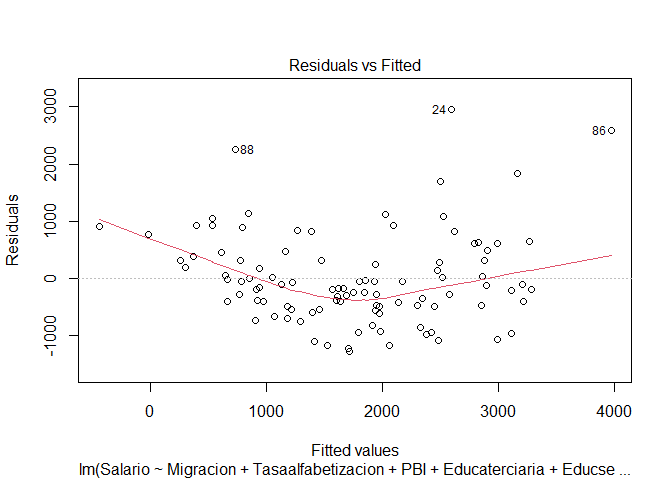

```r
library(ggfortify)
plot(modelo3,1)
```

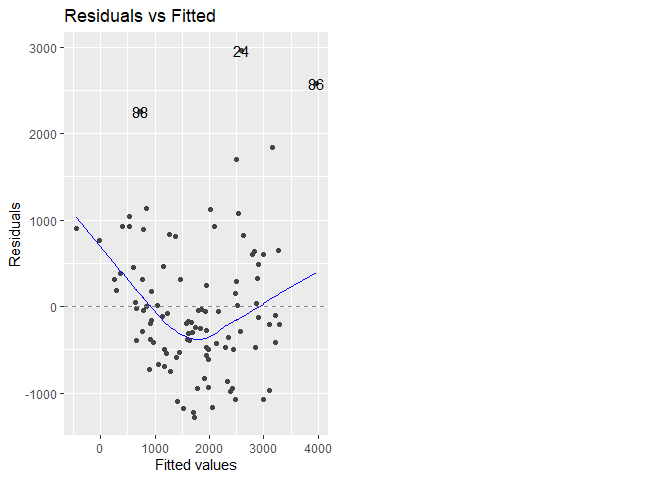

```r
autoplot(modelo3,1)
```

**NORMALIDAD**

```r
shapiro.test(modelo3$resid)
```

```
##
##  Shapiro-Wilk normality test
##
## data:  modelo3$resid
## W = 0.92629, p-value = 2.828e-05
```

*- H0: Es normal*

*- H1: No es normal*

-No hay normalidad de residuos.

**HOMOCEDASTICIDAD**

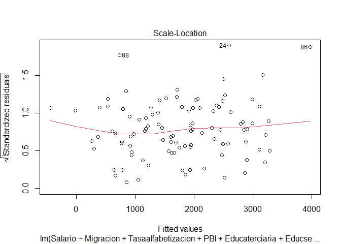

```r
plot(modelo3, 3)
```

```r
library(lmtest)
bptest(modelo3)
```

```
##
##  studentized Breusch-Pagan test
##
## data:  modelo3
## BP = 8.789, df = 9, p-value = 0.457
```

*- H0: El modelo es homocedástico*

*- H1: El modelo es heterocedástico*

*Si el pvalor es menor a 0.05 entonces el modelo es heterocedástico.* No hay heterocedasticidad.

**NO MULTICOLENALIDAD**

```r
library(DescTools)
VIF(modelo3)
```

```
##          Migracion Tasaalfabetizacion                PBI     Educaterciaria
##           1.234394           3.966880           1.394536           1.155858
##          Educsecun      Esperanzavida          Desempleo     Crecimientopob
##           1.482937           2.515997           1.131419           2.060833
##       Electricidad
##           2.830144
```

*Valores > 5 indican presencia de multicolinealidad.* No hay multicolinealidad

**INDEPENDENCIA DE RESIDUOS**

```r
#Default
library(car)
durbinWatsonTest(modelo3)
```

```
##  lag Autocorrelation D-W Statistic p-value
##    1     -0.01020701      2.007446    0.97
##  Alternative hypothesis: rho != 0
```

*Durbin Watson: Las hipótesis son:* *- H0: Los residuos son independientes*

*- H1: Los residuos no son independientes*

Si hay independencia de residuos.

## **COMPARAMOS LOS MODELOS**

```r
library(stargazer)
stargazer(modelo1, modelo2, modelo3, type = "text")
```

```
##
## ========================================================================================
##                                             Dependent variable:
##                     --------------------------------------------------------------------
##                                                   Salario
##                              (1)                    (2)                    (3)
## ----------------------------------------------------------------------------------------
## factor1                   30.988***              19.679***
##                            (4.362)                (6.160)
##
## factor2                     1.986
##                            (7.714)
##
## TasaMigracion                                      0.478*
##                                                   (0.242)
##
## Migracion                                                                 0.0002
##                                                                          (0.001)
##
## Tasaalfabetizacion                                                        2.786
##                                                                          (10.277)
##
## PBI                                                                     -41.703**
##                                                                          (19.309)
##
## Educaterciaria                                                          -895.501**
##                                                                         (356.169)
##
## Educsecun                                                               1,383.080
##                                                                         (935.243)
##
## Esperanzavida                                                           120.168***
##                                                                          (18.428)
##
## Desempleo                                         -21.194                 2.692
##                                                   (19.987)               (18.707)
##
## Crecimientopob                                   -242.992**             -182.812**
##                                                  (100.582)               (87.998)
##
## Electricidad                                                            -15.738**
##                                                                          (7.340)
##
## Constant                   -693.375               586.646             -5,929.656***
##                           (587.063)              (530.307)             (1,597.294)
##
## ----------------------------------------------------------------------------------------
## Observations                 101                    101                    101
## R2                          0.344                  0.397                  0.552
## Adjusted R2                 0.331                  0.372                  0.507
## Residual Std. Error   976.021 (df = 98)      945.904 (df = 96)      837.665 (df = 91)
## F Statistic         25.733*** (df = 2; 98) 15.784*** (df = 4; 96) 12.435*** (df = 9; 91)
## ========================================================================================
## Note:                                                        *p<0.1; **p<0.05; ***p<0.01
```

- El factor 1 es significativo para predecir el salario promedio.
- R cuadrado: es más alto en el modelo 3.

```r
anova(modelo1, modelo2, modelo3)
```

```
## Analysis of Variance Table
##
## Model 1: Salario ~ factor1 + factor2
## Model 2: Salario ~ factor1 + TasaMigracion + Desempleo + Crecimientopob
## Model 3: Salario ~ Migracion + Tasaalfabetizacion + PBI + Educaterciaria +
##     Educsecun + Esperanzavida + Desempleo + Crecimientopob +
##     Electricidad
##   Res.Df      RSS Df Sum of Sq      F    Pr(>F)
## 1     98 93356473
## 2     96 85894436  2   7462037 5.3172  0.006547 **
## 3     91 63853177  5  22041259 6.2824 4.734e-05 ***
## ---
## Signif. codes:  0 '***' 0.001 '**' 0.01 '*' 0.05 '.' 0.1 ' ' 1
```

- El modelo 2 presenta mejoras significativas respecto al modelo 1, según la prueba ANOVA.